**Link to colab:** https://colab.research.google.com/drive/1NgYF9gA1CBKwpzlyMY5OBG9Ba6ENbF5H

**Link to html version (better view than PDF file):** https://raw.githack.com/michaeldybdahl/M2_miniassignements/master/Copy%20of%20M2_2nd%20assignment.html

I recommend to use the HTML version, because there are still some weird overlaps with the pages in the PDF file, but uploaded it as PDF so you have both options.

# Load packages

```r
### Install packages if necessary
if (!require("pacman")) install.packages("pacman") # package for loading and checking packages :)
pacman::p_load(tidyverse, # Standard datasciewnce toolkid (dplyr, ggplot2 et al.)
               magrittr, # For advanced piping (%>% et al.)
               tidytext, # For text analysis
               tm,
               rtweet# text mining library
               )
```

# Load data

```r
twitter <- read_csv("https://raw.githubusercontent.com/michaeldybdahl/M2_miniassignements/master/twitter_hate_speech.csv")
```

```r
head(twitter)
```

A tibble: 6 × 3

| X1 <dbl> | class <dbl> | tweet <chr> |
| --- | --- | --- |
| 0 | 2 | !!! RT @mayasolovely: As a woman you shouldn't complain about cleaning up your house. &amp; as a man you should always take the trash out... |
| 1 | 1 | !!!!! RT @mleew17: boy dats cold...tyga dwn bad for cuffin dat hoe in the 1st place!! |
| 2 | 1 | !!!!!!! RT @UrKindOfBrand Dawg!!!! RT @80sbaby4life: You ever fuck a bitch and she start to cry? You be confused as shit |
| 3 | 1 | !!!!!!!!! RT @C_G_Anderson: @viva_based she look like a tranny |
| 4 | 1 | !!!!!!!!!!!!! RT @ShenikaRoberts: The shit you hear about me might be true or it might be faker than the bitch who told it to ya &#57361; |
| 5 | 1 | !!!!!!!!!!!!!!!!!!"@T_Madison_x: The shit just blows me..claim you so faithful and down for somebody but still fucking with hoes! &#128514;&#128514;&#128514;" |

The first coloumn is "X1" which includes the number observation, where the first observation is "0". I really want this to start with 1, so therefor I create a ID coloumn instead of X1.

```r
twitter$ID <- seq.int(nrow(twitter)) #I create the ID coloumn, where the sequence I set to start with "nrow" (number rows).
```

```r
twitter <- twitter %>% # I want the ID coloumn to be first + I only select ID, class & tweet - so I remove "X1".
  select(ID, class, tweet)
```

```r
head(twitter)
glimpse(twitter)
```

A tibble: 6 × 3

| ID <int> | class <dbl> | tweet <chr> |
| --- | --- | --- |
| 1 | 2 | !!! RT @mayasolovely: As a woman you shouldn't complain about cleaning up your house. &amp; as a man you should always take the trash out... |
| 2 | 1 | !!!!! RT @mleew17: boy dats cold...tyga dwn bad for cuffin dat hoe in the 1st place!! |
| 3 | 1 | !!!!!!! RT @UrKindOfBrand Dawg!!!! RT @80sbaby4life: You ever fuck a bitch and she start to cry? You be confused as shit |
| 4 | 1 | !!!!!!!!! RT @C_G_Anderson: @viva_based she look like a tranny |
| 5 | 1 | !!!!!!!!!!!!! RT @ShenikaRoberts: The shit you hear about me might be true or it might be faker than the bitch who told it to ya &#57361; |
| 6 | 1 | !!!!!!!!!!!!!!!!!!"@T_Madison_x: The shit just blows me..claim you so faithful and down for somebody but still fucking with hoes! &#128514;&#128514;&#128514;" |

```
Observations: 24,783
Variables: 3
$ ID    <int> 1, 2, 3, 4, 5, 6, 7, 8, 9, 10, 11, 12, 13, 14, 15, 16, 17, 18, …
$ class <dbl> 2, 1, 1, 1, 1, 1, 1, 1, 1, 1, 1, 1, 1, 1, 1, 1, 1, 1, 1, 1, 1, …
$ tweet <chr> "!!! RT @mayasolovely: As a woman you shouldn't complain about …
```

# 1. Preprocessing and vectorizaion.

### 1.1.1. Preprocessing (Bag-of-words presentation)

**Transforming data to tidy format.**

I start by transforming the data into a tidy format, where it seperate the words from the tweets and we do not care about the sequencing, which creates these "bag-of-words".

```r
tweets_tidy <- twitter %>%
  select(ID, class, tweet) %>%
  unnest_tokens(output = word, input = tweet)
```

```r
head(tweets_tidy)
```

A tibble: 6 × 3

| ID <int> | class <dbl> | word <chr> |
| --- | --- | --- |
| 1 | 2 | rt |
| 1 | 2 | mayasolovely |
| 1 | 2 | as |
| 1 | 2 | a |
| 1 | 2 | woman |
| 1 | 2 | you |

Above we can see that the words are seperated from the tweets.

Below I want to count the words

```r
tweets_tidy %>%
  count(word, sort = TRUE) %>% # Count "word". "sort = TRUE" means that it will sort the words in descending order of number words.
  head(20)
```

A tibble: 20 × 2

| word <chr> | n <int> |
| --- | --- |
| a | 9526 |
| bitch | 8342 |
| rt | 7644 |
| i | 7632 |
| the | 7205 |
| you | 6167 |
| to | 5342 |
| and | 3989 |
| my | 3590 |
| that | 3551 |
| 128514 | 3241 |
| bitches | 3117 |
| in | 3063 |
| t.co | 2999 |
| is | 2919 |
| http | 2914 |
| like | 2785 |
| me | 2757 |
| of | 2551 |
| on | 2534 |

In the head, we can see that the most common word is "a" followed by "bitch" (:-D).

Allot of the words is stop words and meaningless words, fx "rt" which is just shortterm for "retweet".

**Remove stop words and other meaningless words.**

I want to filter out stop words, where I use the stop_words lexicon from tidytext. Also I want to define some own stop words from the head, that I does not expect to be a part of the stop words lexicon.

```r
own_stopwords <- tibble(word= c("rt", "http", "t.co", "amp"),
                        lexicon = "OWN")
```

```r
tweets_tidy %<>% # I use "%<>%" which both assigns and pipe - instead of first assigning and then piping.
  anti_join(stop_words %>% bind_rows(own_stopwords), by = "word") # I use anti_join instead of filter, because it should be a bit faster.
```

**Remove non-Alphanumeric words & words with only one character.**

In same code, I also filter out words with a lenght at 1, by using the "str_length" function.

```r
tweets_tidy %<>%
  mutate(word = word %>% str_remove_all("[^[:alnum:]]") ) %>% # alnum = Alphanumeric characters.
  filter(str_length(word) > 1) # filter out words with 1 character.
```

**Remove words with numbers.**

I also want to remove the words with numbers and here I use the "gsub" function.

```r
tweets_tidy %<>%
  mutate(word = trimws(gsub("[^\\s]*[0-9][^\\s]*", "", word, perl=T))) %>%
  filter(str_length(word) > 1) # this filter out the words that are blank.
```

```r
tweets_tidy %<>%
  add_count(ID, word, name = "nword") %>%
  add_count(ID, name = "ntweet") %>%
  filter(nword > 1 & ntweet > 5) %>%
    select(-nword, -ntweet)
```

**Checking the cleaned word counts.**

Here I again count the number of times the different words have been used. Afterwards I also plot the top 20 most used words in the tweets.

```r
topwords <- tweets_tidy %>%
  count(word, sort = TRUE)
head(topwords)
```

A tibble: 6 × 2

| word <chr> | n <int> |
| --- | --- |
| bitch | 668 |
| gt | 234 |
| ass | 202 |
| nigga | 178 |
| bitches | 173 |
| hoes | 173 |

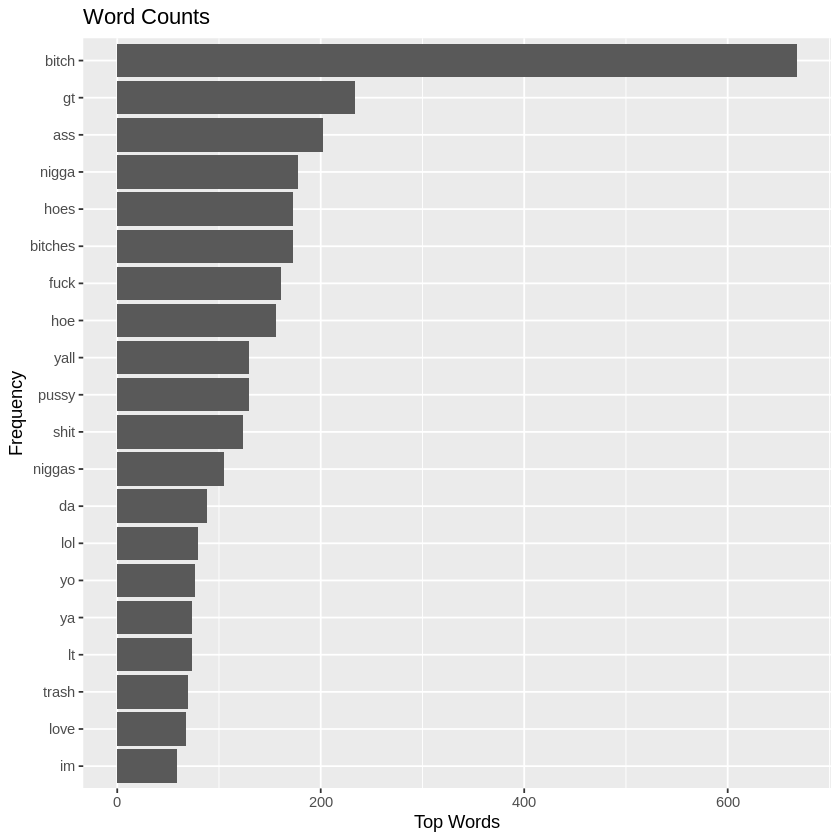

```r
topwords %>%
  top_n(20, n) %>%
  ggplot(aes(x = word %>% fct_reorder(n), y = n)) + #fct_reorder factor the counts + it reorder the counts in a descending format.
  geom_col() +
  coord_flip() +
  labs(title = "Word Counts",
       x = "Frequency",
       y = "Top Words")
```

So we can see that "bitch" is the most used word, and words like "ass", "nigga", "hoes" are also freqently used words. I am not all sure about what "gt" is, but it looks like it means "followe back" (according to google ;-)).

## 1.1.2. TF-IDF

In this section, I apply TF-IDF.

First I assign the TF-IDF tibble from the tweets_tidy.

```r
tweets_tidy1 <- tweets_tidy %>%
  count(ID, word) %>%
  bind_tf_idf(word, ID, n) # I use this function to add the "tf", "idf" & "tf_idf" values.
```

```r
tweets_tidy1 %>%
  arrange(desc(tf_idf))
```

A tibble: 3937 × 6

| ID <int> | word <chr> | n <int> | tf <dbl> | idf <dbl> | tf_idf <dbl> |
| --- | --- | --- | --- | --- | --- |
| 57 | theparadox | 2 | 1 | 8.04719 | 8.04719 |
| 122 | aw | 2 | 1 | 8.04719 | 8.04719 |
| 140 | outta | 2 | 1 | 8.04719 | 8.04719 |
| 147 | anelylove | 2 | 1 | 8.04719 | 8.04719 |
| 153 | pornhub | 2 | 1 | 8.04719 | 8.04719 |
| 159 | peel | 2 | 1 | 8.04719 | 8.04719 |
| 160 | io | 2 | 1 | 8.04719 | 8.04719 |
| 181 | mlbnetwork | 2 | 1 | 8.04719 | 8.04719 |
| 184 | cowboy | 2 | 1 | 8.04719 | 8.04719 |
| 201 | obsessed | 2 | 1 | 8.04719 | 8.04719 |
| 207 | tired | 2 | 1 | 8.04719 | 8.04719 |
| 213 | dancers | 2 | 1 | 8.04719 | 8.04719 |
| 219 | tree | 2 | 1 | 8.04719 | 8.04719 |
| 237 | brothers | 2 | 1 | 8.04719 | 8.04719 |
| 262 | test | 2 | 1 | 8.04719 | 8.04719 |
| 288 | fucc | 3 | 1 | 8.04719 | 8.04719 |
| 290 | punch | 2 | 1 | 8.04719 | 8.04719 |
| 333 | angelique | 2 | 1 | 8.04719 | 8.04719 |
| 347 | jaimescudi | 2 | 1 | 8.04719 | 8.04719 |
| 371 | easily | 2 | 1 | 8.04719 | 8.04719 |
| 374 | brunos | 2 | 1 | 8.04719 | 8.04719 |
| 393 | sox | 2 | 1 | 8.04719 | 8.04719 |
| 395 | socass | 2 | 1 | 8.04719 | 8.04719 |
| 413 | meat | 2 | 1 | 8.04719 | 8.04719 |
| 419 | political | 2 | 1 | 8.04719 | 8.04719 |
| 469 | handle | 2 | 1 | 8.04719 | 8.04719 |
| 472 | picture | 2 | 1 | 8.04719 | 8.04719 |
| 517 | mama | 2 | 1 | 8.04719 | 8.04719 |
| 524 | ongesteld | 2 | 1 | 8.04719 | 8.04719 |
| 542 | freestyles | 2 | 1 | 8.04719 | 8.04719 |
| ⋮ | ⋮ | ⋮ | ⋮ | ⋮ | ⋮ |
| 14323 | bitch | 2 | 0.3333333 | 2.320342 | 0.7734473 |
| 15459 | bitch | 5 | 0.3333333 | 2.320342 | 0.7734473 |
| 15569 | bitch | 2 | 0.3333333 | 2.320342 | 0.7734473 |
| 16136 | bitch | 2 | 0.3333333 | 2.320342 | 0.7734473 |
| 16474 | bitch | 2 | 0.3333333 | 2.320342 | 0.7734473 |
| 16689 | bitch | 2 | 0.3333333 | 2.320342 | 0.7734473 |
| 16856 | bitch | 2 | 0.3333333 | 2.320342 | 0.7734473 |
| 18445 | bitch | 2 | 0.3333333 | 2.320342 | 0.7734473 |
| 19862 | bitch | 2 | 0.3333333 | 2.320342 | 0.7734473 |
| 20419 | bitch | 2 | 0.3333333 | 2.320342 | 0.7734473 |
| 21691 | bitch | 2 | 0.3333333 | 2.320342 | 0.7734473 |
| 21943 | bitch | 2 | 0.3333333 | 2.320342 | 0.7734473 |
| 22015 | bitch | 2 | 0.3333333 | 2.320342 | 0.7734473 |
| 23794 | bitch | 2 | 0.3333333 | 2.320342 | 0.7734473 |
| 13080 | word | 2 | 0.1111111 | 6.948577 | 0.7720641 |
| 7467 | nigga | 2 | 0.2000000 | 3.665163 | 0.7330326 |
| 464 | hoes | 2 | 0.2000000 | 3.652740 | 0.7305481 |
| 22383 | im | 2 | 0.1538462 | 4.714985 | 0.7253823 |
| 4183 | bitch | 2 | 0.2857143 | 2.320342 | 0.6629548 |
| 17508 | bitch | 2 | 0.2857143 | 2.320342 | 0.6629548 |
| 23370 | bitch | 2 | 0.2857143 | 2.320342 | 0.6629548 |
| 16043 | bitch | 2 | 0.2500000 | 2.320342 | 0.5800855 |
| 16188 | bitch | 2 | 0.2500000 | 2.320342 | 0.5800855 |
| 18874 | bitch | 2 | 0.2500000 | 2.320342 | 0.5800855 |
| 23760 | bitch | 2 | 0.2500000 | 2.320342 | 0.5800855 |
| 3465 | bitch | 2 | 0.2222222 | 2.320342 | 0.5156315 |
| 15491 | bitch | 2 | 0.2222222 | 2.320342 | 0.5156315 |
| 1717 | bitch | 2 | 0.2000000 | 2.320342 | 0.4640684 |
| 8067 | bitch | 2 | 0.2000000 | 2.320342 | 0.4640684 |
| 12939 | bitch | 2 | 0.1666667 | 2.320342 | 0.3867236 |

We can see that the words s with the lowest td-idf is the bitch words, that have a low tf (low proportion of word in tweets) and low idf values (common word in the tweets).

Also the words with highest td-idf, are fx pornhub, most because a high idf value, which means it is uncommon in the tweets - so apparantly not many tweet something with "pornhub" inside (makes sence i quess :D).

## 1.1.3. Latent Semantic Analysis (LSA)

Here I use LSA topic modelling to reduce dimensions.

```r
pacman::p_load(quanteda) # I load quanteda that contain the LSA function.
```

I start by creating a document features matrix, which I need for the LSA modelling.

```r
tweets_dfm <- tweets_tidy %>%
  count(ID, word) %>%
  cast_dfm(document = ID, term = word, value = n)
```

Let us just check the documents features matrix with a wordcloud.

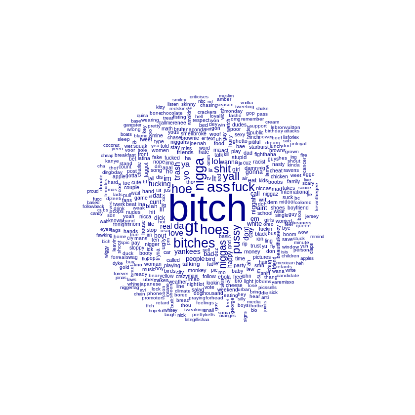

```r
textplot_wordcloud(tweets_dfm)
```

Again we can see that "bitch" is the most represented word in the tweets.

Now I fit the LSA model by using "textmodel_lsa", where the only argument inside is the document features matrix.

```r
tweets_lsa <- tweets_dfm %>%
  textmodel_lsa()
```

```r
tweets_lsa %>% glimpse()
```

```
List of 5
 $ sk             : num [1:10] 39.6 36 22.3 20.9 20.1 ...
 $ docs           : num [1:3125, 1:10] 8.64e-04 3.25e-04 5.61e-04 1.60e-04 -5.85e-19 ...
  ..- attr(*, "dimnames")=List of 2
  .. ..$ : chr [1:3125] "24" "28" "43" "52" ...
  .. ..$ : NULL
 $ features       : num [1:1485, 1:10] 1.71e-02 6.43e-03 1.07e-02 2.83e-05 3.86e-04 ...
  ..- attr(*, "dimnames")=List of 2
  .. ..$ : chr [1:1485] "fuck" "pussy" "bad" "nice" ...
  .. ..$ : NULL
 $ matrix_low_rank: num [1:3125, 1:1485] 1.96 5.44e-03 -1.60e-03 1.09e-01 -3.26e-18 ...
  ..- attr(*, "dimnames")=List of 2
  .. ..$ : chr [1:3125] "24" "28" "43" "52" ...
  .. ..$ : chr [1:1485] "fuck" "pussy" "bad" "nice" ...
 $ data           :Formal class 'dgCMatrix' [package "Matrix"] with 6 slots
  .. ..@ i       : int [1:3937] 0 14 67 215 235 240 311 324 330 331 ...
  .. ..@ p       : int [1:1486] 0 74 133 151 152 174 236 237 242 244 ...
  .. ..@ Dim     : int [1:2] 3125 1485
  .. ..@ Dimnames:List of 2
  .. ..@ x       : num [1:3937] 2 2 2 2 2 2 2 2 2 2 ...
  .. ..@ factors : list()
 - attr(*, "class")= chr "textmodel_lsa"
```

Here I transform the LSA to a dataframe, that I can use later in task 3.

```r
tweets_lsa_loading <- tweets_lsa$docs %>%
  as.data.frame() %>%
  rownames_to_column(var = "ID") %>%
  as_tibble()
```

```r
tweets_lsa_loading %>% head()
```

A tibble: 6 × 11

| ID <chr> | V1 <dbl> | V2 <dbl> | V3 <dbl> | V4 <dbl> | V5 <dbl> | V6 <dbl> | V7 <dbl> | V8 <dbl> | V9 <dbl> | V10 <dbl> |
| --- | --- | --- | --- | --- | --- | --- | --- | --- | --- | --- |
| 24 | 8.640783e-04 | 1.914504e-05 | -1.671813e-02 | 2.196958e-02 | -2.157302e-02 | 7.699569e-03 | 2.126166e-02 | 2.332654e-02 | -9.165027e-02 | -9.481222e-07 |
| 28 | 3.252619e-04 | 6.856442e-06 | 1.017857e-04 | -3.265719e-04 | -2.419159e-04 | -8.657279e-05 | 7.724694e-05 | 1.235020e-04 | -3.348262e-04 | 5.956584e-06 |
| 43 | 5.607459e-04 | 1.143494e-05 | -1.729712e-03 | -3.560819e-04 | -7.406342e-04 | -1.585232e-03 | 2.802088e-03 | 5.803375e-03 | 2.688586e-03 | 7.737350e-07 |
| 52 | 1.604911e-04 | 3.378764e-06 | -6.165647e-04 | 3.667888e-04 | -4.588519e-03 | -2.203312e-03 | 5.199036e-04 | 1.201102e-04 | -5.215598e-03 | 1.215874e-06 |
| 57 | -5.846167e-19 | -1.785398e-19 | -4.664621e-19 | 5.520667e-19 | 1.048687e-18 | 3.393245e-19 | 4.435593e-20 | -5.890216e-19 | 6.517659e-20 | -2.110690e-19 |
| 63 | 3.252619e-04 | 6.856442e-06 | 1.017857e-04 | -3.265719e-04 | -2.419159e-04 | -8.657279e-05 | 7.724694e-05 | 1.235020e-04 | -3.348262e-04 | 5.956584e-06 |

```r
pacman::p_load(uwot, # for UMAP
       dbscan # For density based clustering
       )
```

```r
tweets_lsa_umap <- umap(tweets_lsa_loading %>% column_to_rownames("ID"),
                       n_neighbors = 15, metric = "cosine", min_dist = 0.01, scale = TRUE,
                       verbose = TRUE, n_threads = 8)
```

```
06:24:57 Scaling to zero mean and unit variance
06:24:57 Kept 10 non-zero-variance columns
06:24:59 2639 smooth knn distance failures
06:25:00 Found 10 connected components, falling back to 'spca' initialization with init_sdev = 1
06:25:00 PCA: 2 components explained 21.45% variance
```

```r
tweets_lsa_umap %<>% as.data.frame()
```

```r
tweets_lsa_hdbscan <- tweets_lsa_umap %>% as.matrix() %>% hdbscan(minPts = 500)
```

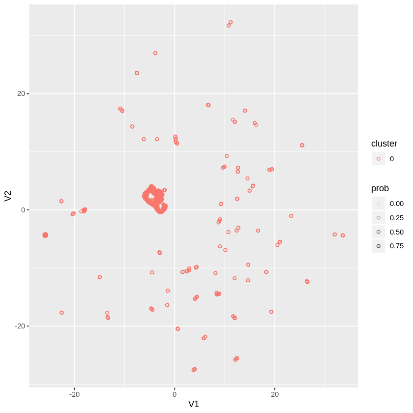

```r
tweets_lsa_umap %>%
  bind_cols(cluster = tweets_lsa_hdbscan$cluster %>% as.factor(),
            prob = tweets_lsa_hdbscan$membership_prob) %>%
  ggplot(aes(x = V1, y = V2, col = cluster)) +
  geom_point(aes(alpha = prob), shape = 21)
```

Both the dataframe and the plot does not really give much meaningfull information at the moment, except it looks like some of the features cluster in the middle. Maybe this is the class 0 and 1?

## 1.2. Train a word-embedding model (GloVe)

```r
pacman::p_load(text2vec)
```

```r
tweets_corpus <- twitter %>% corpus(docid_field = "ID", text_field = "tweet")
```

```r
tweet_toks <- tokens(tweets_corpus, what = "word") %>%
  tokens_tolower() %>%
  tokens(remove_punct = TRUE,
         remove_symbols = TRUE)
```

```r
feats <- dfm(tweet_toks, verbose = TRUE) %>%
  dfm_trim(min_termfreq = 5) %>%
  featnames()
```

```
Creating a dfm from a tokens input...
   ... lowercasing
   ... found 24,783 documents, 37,711 features
   ... created a 24,783 x 37,711 sparse dfm
   ... complete.
Elapsed time: 0.225 seconds.
```

```r
tweet_fcm <- fcm(tweet_toks,
                 context = "window",
                 count = "weighted",
                 weights = 1 / (1:5),
                 tri = TRUE)
```

```r
glove <- GlobalVectors$new(word_vectors_size = 50, vocabulary = featnames(tweet_fcm), x_max = 10)
```

```r
tweet_word_vectors <- fit_transform(tweet_fcm, glove, n_iter = 20)
```

```
INFO [2019-10-17 06:25:28] 2019-10-17 06:25:28 - epoch 1, expected cost 0.0726
INFO [2019-10-17 06:25:29] 2019-10-17 06:25:29 - epoch 2, expected cost 0.0488
INFO [2019-10-17 06:25:29] 2019-10-17 06:25:29 - epoch 3, expected cost 0.0398
INFO [2019-10-17 06:25:30] 2019-10-17 06:25:30 - epoch 4, expected cost 0.0349
INFO [2019-10-17 06:25:30] 2019-10-17 06:25:30 - epoch 5, expected cost 0.0315
INFO [2019-10-17 06:25:31] 2019-10-17 06:25:31 - epoch 6, expected cost 0.0289
INFO [2019-10-17 06:25:32] 2019-10-17 06:25:32 - epoch 7, expected cost 0.0268
INFO [2019-10-17 06:25:32] 2019-10-17 06:25:32 - epoch 8, expected cost 0.0250
INFO [2019-10-17 06:25:33] 2019-10-17 06:25:33 - epoch 9, expected cost 0.0236
INFO [2019-10-17 06:25:33] 2019-10-17 06:25:33 - epoch 10, expected cost 0.0223
INFO [2019-10-17 06:25:34] 2019-10-17 06:25:34 - epoch 11, expected cost 0.0211
INFO [2019-10-17 06:25:34] 2019-10-17 06:25:34 - epoch 12, expected cost 0.0202
INFO [2019-10-17 06:25:35] 2019-10-17 06:25:35 - epoch 13, expected cost 0.0193
INFO [2019-10-17 06:25:35] 2019-10-17 06:25:35 - epoch 14, expected cost 0.0185
INFO [2019-10-17 06:25:36] 2019-10-17 06:25:36 - epoch 15, expected cost 0.0178
INFO [2019-10-17 06:25:37] 2019-10-17 06:25:37 - epoch 16, expected cost 0.0172
INFO [2019-10-17 06:25:37] 2019-10-17 06:25:37 - epoch 17, expected cost 0.0166
INFO [2019-10-17 06:25:38] 2019-10-17 06:25:38 - epoch 18, expected cost 0.0161
INFO [2019-10-17 06:25:38] 2019-10-17 06:25:38 - epoch 19, expected cost 0.0156
INFO [2019-10-17 06:25:39] 2019-10-17 06:25:39 - epoch 20, expected cost 0.0152
```

```r
tweet_word_vectors %<>% as.data.frame() %>%
  rownames_to_column(var = "word") %>%
  as_tibble()
```

```r
tweet_word_vectors %>% head()
```

A tibble: 6 × 51

| word <chr> | V1 <dbl> | V2 <dbl> | V3 <dbl> | V4 <dbl> | V5 <dbl> | V6 <dbl> | V7 <dbl> | V8 <dbl> | V9 <dbl> | ⋯ | V41 <dbl> | V42 <dbl> | V43 <dbl> | V44 <dbl> | V45 <dbl> | V46 <dbl> | V47 <dbl> | V48 <dbl> | V49 <dbl> | V50 <dbl> |
| --- | --- | --- | --- | --- | --- | --- | --- | --- | --- | --- | --- | --- | --- | --- | --- | --- | --- | --- | --- | --- |
| rt | -0.07154012 | 0.3404917 | 0.22068171 | 0.1475162 | -0.56722826 | -0.49848849 | -0.58714455 | 0.6602918 | 0.284184903 | ⋯ | 0.37221941 | -0.3125014305 | 0.1485835 | -0.88079524 | -0.1653029 | 0.10747164 | -0.001873329 | 0.02856129 | 0.6883760 | -0.11870557 |
| @mayasolovely | -0.57237828 | 0.3435081 | -0.31236905 | 0.3060358 | -0.33000255 | 0.27926660 | 0.04415545 | 0.2243392 | 0.151413873 | ⋯ | -0.24796563 | -0.2768101394 | -0.3852893 | 0.53285235 | 0.1830021 | 0.20311181 | 0.204343259 | -0.28754136 | -0.2955619 | 0.21551135 |
| as | 0.13240860 | 0.1845374 | 0.17576289 | 0.2850434 | 0.07057026 | 0.02195043 | -0.56552792 | 0.3856841 | -0.176168323 | ⋯ | 0.45110050 | -0.0005687422 | 0.2424813 | -0.06496287 | -0.5513117 | -0.50406462 | 0.232973158 | -0.20917261 | 0.5191535 | -0.21907695 |
| a | -0.13229209 | 0.3743483 | 0.05505052 | 0.5413024 | -0.01595370 | 0.51719481 | -0.83366597 | 0.6068351 | -0.722611010 | ⋯ | -0.16767977 | -0.3723386228 | -0.5047171 | 0.22513181 | -0.9677101 | -0.40109396 | 0.304667681 | -0.16409527 | 0.4080443 | -0.07050736 |
| woman | -0.16888957 | 0.1679473 | -0.27680790 | -0.1483791 | -0.19699332 | 0.22007595 | -0.19413784 | 0.1473113 | -0.009949556 | ⋯ | 0.06222236 | 0.3763740361 | -0.6559605 | -0.10420775 | -0.4364572 | -0.46450955 | 0.540489852 | 0.80605686 | 0.2521331 | 0.21978335 |
| you | 0.15924864 | 0.3731202 | 0.29706818 | 0.5584623 | -0.21972042 | -0.18738866 | -0.64332300 | 0.6334170 | -0.566488206 | ⋯ | -0.07936440 | 0.0175970905 | -0.2870002 | 0.09284240 | -0.7842730 | -0.06608823 | -0.091870718 | -0.08228717 | 0.1802623 | -0.59102571 |

```r
tweets_tidy2 <- tweet_toks %>%
  dfm() %>%
  tidy()
```

```r
tweet_vectors <- tweets_tidy2 %>%
  inner_join(tweet_word_vectors, by = c("term" = "word"))
```

```r
tweet_vectors %>% head()
```

A tibble: 6 × 53

| document <chr> | term <chr> | count <dbl> | V1 <dbl> | V2 <dbl> | V3 <dbl> | V4 <dbl> | V5 <dbl> | V6 <dbl> | V7 <dbl> | ⋯ | V41 <dbl> | V42 <dbl> | V43 <dbl> | V44 <dbl> | V45 <dbl> | V46 <dbl> | V47 <dbl> | V48 <dbl> | V49 <dbl> | V50 <dbl> |
| --- | --- | --- | --- | --- | --- | --- | --- | --- | --- | --- | --- | --- | --- | --- | --- | --- | --- | --- | --- | --- |
| 1 | rt | 1 | -0.07154012 | 0.3404917 | 0.2206817 | 0.1475162 | -0.5672283 | -0.4984885 | -0.5871446 | ⋯ | 0.3722194 | -0.3125014 | 0.1485835 | -0.8807952 | -0.1653029 | 0.1074716 | -0.001873329 | 0.02856129 | 0.688376 | -0.1187056 |
| 2 | rt | 1 | -0.07154012 | 0.3404917 | 0.2206817 | 0.1475162 | -0.5672283 | -0.4984885 | -0.5871446 | ⋯ | 0.3722194 | -0.3125014 | 0.1485835 | -0.8807952 | -0.1653029 | 0.1074716 | -0.001873329 | 0.02856129 | 0.688376 | -0.1187056 |
| 3 | rt | 2 | -0.07154012 | 0.3404917 | 0.2206817 | 0.1475162 | -0.5672283 | -0.4984885 | -0.5871446 | ⋯ | 0.3722194 | -0.3125014 | 0.1485835 | -0.8807952 | -0.1653029 | 0.1074716 | -0.001873329 | 0.02856129 | 0.688376 | -0.1187056 |
| 4 | rt | 1 | -0.07154012 | 0.3404917 | 0.2206817 | 0.1475162 | -0.5672283 | -0.4984885 | -0.5871446 | ⋯ | 0.3722194 | -0.3125014 | 0.1485835 | -0.8807952 | -0.1653029 | 0.1074716 | -0.001873329 | 0.02856129 | 0.688376 | -0.1187056 |
| 5 | rt | 1 | -0.07154012 | 0.3404917 | 0.2206817 | 0.1475162 | -0.5672283 | -0.4984885 | -0.5871446 | ⋯ | 0.3722194 | -0.3125014 | 0.1485835 | -0.8807952 | -0.1653029 | 0.1074716 | -0.001873329 | 0.02856129 | 0.688376 | -0.1187056 |
| 57 | rt | 1 | -0.07154012 | 0.3404917 | 0.2206817 | 0.1475162 | -0.5672283 | -0.4984885 | -0.5871446 | ⋯ | 0.3722194 | -0.3125014 | 0.1485835 | -0.8807952 | -0.1653029 | 0.1074716 | -0.001873329 | 0.02856129 | 0.688376 | -0.1187056 |

```r
tweet_vectors %<>%
  select(-term, -count) %>%
  group_by(document) %>%
  summarise_all(mean)
```

```r
tweet_vectors_umap <- umap(tweet_vectors %>% column_to_rownames("document"),
                       n_neighbors = 15,
                       metric = "cosine",
                       min_dist = 0.01,
                       scale = TRUE,
                       verbose = TRUE) %>%
  as.data.frame()
```

```
06:25:53 Scaling to zero mean and unit variance
06:25:53 Kept 50 non-zero-variance columns
06:26:09 13 smooth knn distance failures
```

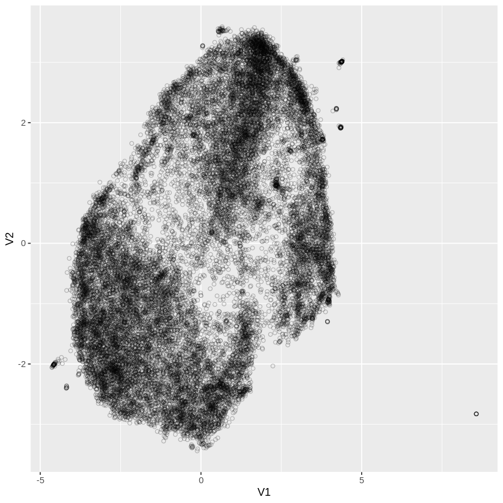

```r
tweet_vectors_umap %>%
  ggplot(aes(x = V1, y = V2)) +
  geom_point(shape = 21, alpha = 0.25)
```

# 2. Explore and compare the 2 "classes of interest" - hate speech vs offensive language.

## 2.1. Can you see differences by using simple count-based approaches?

Here I simple count the "class" from the twitter datasat, to see how many tweets are in the 3 classes.

```r
twitter %>%
  count(class)
```

A tibble: 3 × 2

| class <dbl> | n <int> |
| --- | --- |
| 0 | 1430 |
| 1 | 19190 |
| 2 | 4163 |

```r
glimpse(twitter)
```

```
Observations: 24,783
Variables: 3
$ ID    <int> 1, 2, 3, 4, 5, 6, 7, 8, 9, 10, 11, 12, 13, 14, 15, 16, 17, 18, …
$ class <dbl> 2, 1, 1, 1, 1, 1, 1, 1, 1, 1, 1, 1, 1, 1, 1, 1, 1, 1, 1, 1, 1, …
$ tweet <chr> "!!! RT @mayasolovely: As a woman you shouldn't complain about …
```

So there is not that many hate speech (5,7%) vs offensive language (77,4%) - and around 16% classes as neither.

Overall the tweets are mostly classes as offensive language.

## 2.2. Identifying themes

### 2.2.1. Using topic model (LSA)

First I will use kmeans for clustering the LSA topic model.

```r
kmeans_lsa <- kmeans(tweets_lsa_loading, centers = 3, nstart = 20) # I set centers to 3, because I expect the LSA to cluster by the 3 classes (perhaps)
```

```r
tweets_lsa_loading2 <- tweets_lsa_loading %>%
  mutate(ID = as.double(ID)) %>%
  left_join(twitter, by = "ID") # I use left_join, so I merge the class coloumn into the LSA matrix.
```

Then I use a crosstabs with the classes from the LSA model in the rows and have the clusters at the coloumns. Here I will try to see if I can identify if any of the clusters are specific to the classes.

```r
table(tweets_lsa_loading2$class, kmeans_lsa$cluster)
```

```
      1   2   3
  0  56  53  73
  1 928 908 618
  2 158 211 120
```

Well I cant really identify any clear clusters that are specific to the classes. This could might indicate that there are not such a big different in the word counts at the three classes.

Therefor I will try plot the must frequent words in the 3 classes below.

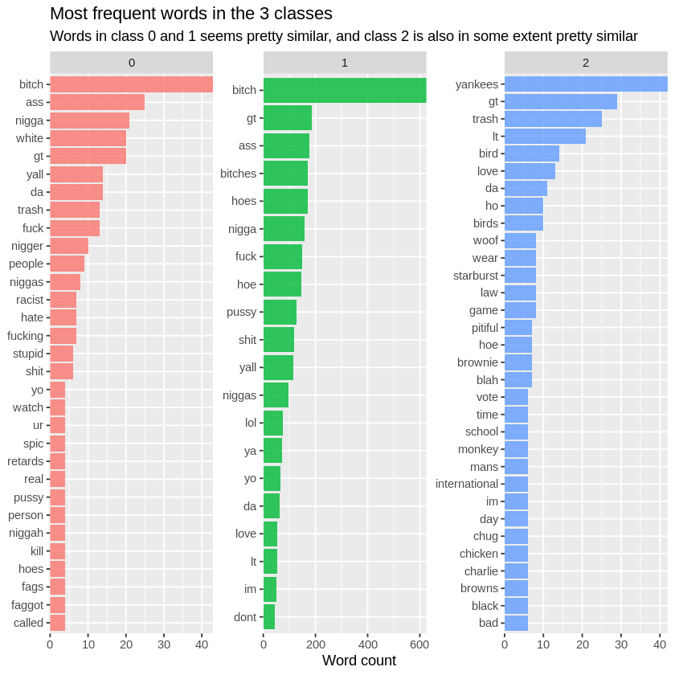

```r
tweets_tidy %>%
  mutate(class = as.factor(class)) %>%
  count(class, word, sort = TRUE) %>%
  group_by(class) %>%
  top_n(20) %>%
  ungroup() %>%
  ggplot(aes(reorder_within(word, n, class), n,
    fill = class
  )) +
  geom_col(alpha = 0.8, show.legend = FALSE) +
  scale_x_reordered() +
  coord_flip() +
  facet_wrap(~class, scales = "free") +
  scale_y_continuous(expand = c(0, 0)) +
  labs(
    x = NULL, y = "Word count",
    title = "Most frequent words in the 3 classes",
    subtitle = "Words in class 0 and 1 seems pretty similar, and class 2 is also in some extent pretty similar"
  )
```

Looking at the plots, it looks like class 0 (hate speech) and class 1 (offensive language), has many of the same words and therefor are maybe close to each other.

Also the class 2 (neither), has some of the common words as class 1 - fx gt, love, hoe/hoes, but has also alot more "neutral" words.

### 2.2.2. Using TD-IDF

Now I want to find clusters in the TD-IDF matrix.

```r
tweets_tidy2 <- tweets_tidy1 %>%
   mutate(ID = as.double(ID)) %>%
  left_join(twitter, by = "ID") # I use left_join, so I merge the class coloumn into the TD-IDF matrix.
```

```r
kmeans_TDIDF <- kmeans(tweets_tidy2[,4:6], centers = 3, nstart = 20) # I only choose coloumns 4:6 which is the if, idf & td-idf values to cluster.
```

```r
table(tweets_tidy2$class, kmeans_TDIDF$cluster)
```

```
       1    2    3
  0   81   39  110
  1 1086  631 1384
  2  327  194   85
```

Here I can see that cluster 3 has allot of the words from class 0 and 1 (hate speech & offensive language), and a small portion of the class 2.

Below I want to see that means for the three clusters.

```r
tweets_tidy2 %>%
  bind_cols(cluster = kmeans_TDIDF$cluster) %>%
  group_by(cluster) %>%
  mutate(n = n()) %>%
  summarise_all(funs(mean))
```

A tibble: 3 × 9

| cluster <int> | ID <dbl> | word <dbl> | n <dbl> | tf <dbl> | idf <dbl> | tf_idf <dbl> | class <dbl> | tweet <dbl> |
| --- | --- | --- | --- | --- | --- | --- | --- | --- |
| 1 | 12776.24 | NA | 1494 | 0.9994794 | 7.215029 | 7.210973 | 1.1646586 | NA |
| 2 | 13499.82 | NA | 864 | 0.4365981 | 7.411777 | 3.234097 | 1.1793981 | NA |
| 3 | 12645.97 | NA | 1579 | 0.7945263 | 3.850829 | 3.041606 | 0.9841672 | NA |

**Cluster 1**: The cluster with high tf & idf values, which indicate that this is the more uncommon words in the weets. In the crosstab earlier, this indicate that it is alot of the class 1 and 2 that is in here.

**Cluster 2**: The smallest cluster with low tf (low proportion of words in the tweets) & a high idf value (uncommon words in the tweets). This cluster did not have many hate speech and offensive language tweets, which probably is because it is uncommon words and they are not highly represented in the tweets.

**Cluster 3**: This has "medium" tf and a low idf value (most common words). Here hate speech and offensive language was highly represented, which is proably because of the the common words as fx bitch.

# 3. Build an ML model that can predict hate speech

In this section I am going to try create three classification models using the LSA model (I tried using the TD-IDF, but didnt worked and could not find a solution).

**Add logical variable:**

First I create a new variable "hate_speech" in the LSA matrix.

```r
tweets_lsa_loading_ML <- tweets_lsa_loading2 %>%
  select(2:12) %>%
  mutate(hate_speech = as.logical(class==0, class)) # I set class == 0, so class 0 is TRUE and the rest FALSE:
```

**Load caret and recipes package.**

I load caret and recipes, which I need for the preprocessing and training the data.

```r
pacman::p_load(caret, recipes)
```

**Splitting the data into train- and test set.**

```r
index <- createDataPartition(y = tweets_lsa_loading_ML$hate_speech, p = 0.75, list = FALSE) # 75% to 25% split
training <- tweets_lsa_loading_ML[index,]
test <- tweets_lsa_loading_ML[-index,]
```

**Preprocessing using the recipes package.**

```r
reci <- recipe(hate_speech ~ ., data = training) %>%
  step_center(all_numeric(), -all_outcomes()) %>% # Centers all numeric variables to mean = 0
  step_scale(all_numeric(), -all_outcomes()) %>% # this scales the numeric variables
  step_zv(all_predictors())  # Removed predictors with zero variance

reci %<>%
  prep(data = train)
```

**Setting the x and y values**

```r
# Predictors
x_train <-bake(reci, new_data = training) %>% select(-hate_speech,-class) # I remove class from the predictors.
y_train <- training %>% pull(hate_speech) %>% as.factor()
# test: split in y and x
x_test <-bake(reci, new_data = test) %>% select(-hate_speech,-class)
y_test <- test %>% pull(hate_speech) %>% as.factor()
```

**Setting the workflow**

```r
ctrl <- trainControl(method = "cv",
                     number = 4)
metric <- "Kappa" # I use Kappa because the class 0 (hate speech) is so low represented in the data.
```

```r
install.packages('e1071', dependencies=TRUE)
```

## 3.1. Log model

**Fitting the model.**

```r
class_fit_log <- train(x = x_train,
                 y = y_train,
                 trControl = ctrl,
                 metric = metric,
                 method = "glm", family = "binomial")
```

```r
class_fit_log
```

```
Generalized Linear Model

2345 samples
  10 predictor
   2 classes: 'FALSE', 'TRUE'

No pre-processing
Resampling: Cross-Validated (4 fold)
Summary of sample sizes: 1758, 1759, 1759, 1759
Resampling results:

  Accuracy   Kappa
  0.9411517  -0.0008316212
```

**Predicting the fitted model.**

```r
pred_log <- predict(class_fit_log, newdata = x_test)
```

```r
confusionMatrix(pred_log, y_test, positive = 'TRUE')
```

```
Confusion Matrix and Statistics

          Reference
Prediction FALSE TRUE
     FALSE   735   45
     TRUE      0    0

               Accuracy : 0.9423
                 95% CI : (0.9236, 0.9576)
    No Information Rate : 0.9423
    P-Value [Acc > NIR] : 0.5396

                  Kappa : 0

 Mcnemar's Test P-Value : 5.412e-11

            Sensitivity : 0.00000
            Specificity : 1.00000
         Pos Pred Value :     NaN
         Neg Pred Value : 0.94231
             Prevalence : 0.05769
         Detection Rate : 0.00000
   Detection Prevalence : 0.00000
      Balanced Accuracy : 0.50000

       'Positive' Class : TRUE
```

**Performance evaluation:**

Well the log model does not predict any hate speech at all -> sensivity = 0.

Therefor the model is not useable to predict hate speeches.

## 3.2. Randomforest model

```r
pacman::p_load(ranger)
```

**Fitting the model.**

```r
tweet_fit_rf <- train(x = x_train,
                y = y_train,
                trControl = ctrl,
                metric = metric,
                method = "ranger",
                importance = "impurity", # To define how to measure variable importantce (later more)
                num.trees = 25
                )
```

```r
tweet_fit_rf
```

```
Random Forest

2345 samples
  10 predictor
   2 classes: 'FALSE', 'TRUE'

No pre-processing
Resampling: Cross-Validated (4 fold)
Summary of sample sizes: 1758, 1759, 1759, 1759
Resampling results across tuning parameters:

  mtry  splitrule   Accuracy   Kappa
   2    gini        0.9351827  0.11172239
   2    extratrees  0.9364611  0.06802829
   6    gini        0.9347546  0.14460161
   6    extratrees  0.9347553  0.11950724
  10    gini        0.9339035  0.12507574
  10    extratrees  0.9368877  0.14555204

Tuning parameter 'min.node.size' was held constant at a value of 1
Kappa was used to select the optimal model using the largest value.
The final values used for the model were mtry = 10, splitrule = extratrees
 and min.node.size = 1.
```

**Predicting the fitted model.**

```r
pred_rf <- predict(tweet_fit_rf, newdata = x_test)
```

```r
confusionMatrix(pred_rf, y_test, positive = 'TRUE')
```

```
Confusion Matrix and Statistics

          Reference
Prediction FALSE TRUE
     FALSE   721   45
     TRUE     14    0

               Accuracy : 0.9244
                 95% CI : (0.9035, 0.9419)
    No Information Rate : 0.9423
    P-Value [Acc > NIR] : 0.9842

                  Kappa : -0.0282

 Mcnemar's Test P-Value : 9.397e-05

            Sensitivity : 0.00000
            Specificity : 0.98095
         Pos Pred Value : 0.00000
         Neg Pred Value : 0.94125
             Prevalence : 0.05769
         Detection Rate : 0.00000
   Detection Prevalence : 0.01795
      Balanced Accuracy : 0.49048

       'Positive' Class : TRUE
```

**Performance evaluation:**

Well the RF model does not predict any correct hate speech tweets -> sensivity = 0. Although the model predict 14 TRE values, all these where really FALSE.

Therefor the model is not useable to predict hate speeches.

## 3.3. Decisiontree model

**Fitting the model.**

```r
tweet_fit_dt <- train(x = x_train,
                y = y_train,
trControl = ctrl,
metric = metric,
method = "rpart")
```

```r
tweet_fit_dt
```

[output not shown]

**Predicting the fitted model.**

```r
pred_dt <- predict(tweet_fit_dt, newdata = x_test)
```

```r
confusionMatrix(pred_dt, y_test, positive = 'TRUE')
```

[output not shown]

**Performance evaluation:**

This model is much better than the log and RF models. It has a sensitivity at 0.40, which means that it predicts 40% correct hate speech tweets.

The positive pred value is 76,66%, so it predict 76,66% if the predicted TRUE values correct.

## 3.4. Conclusion.

Apparently the decision three model is the only reasonable classification model to predict the hate speech and with a little engineering, the sensivity could maybe be a bit better.

# 4.

[figure not shown]